# IE582_HW2

Ufuk Ustundag

10 December 2020

### Installing Packages

```r
library(readxl)
library(data.table)
```

```r
library(stringr)
library(ggplot2)
library(scatterplot3d)
```

# DATA MANIPULATION

### Inserting Data

```r
file.exists('C:/Users/ufuk9/Desktop/IE582_HW2_data_x.xlsx')
```

```
## [1] TRUE
```

```r
file.exists('C:/Users/ufuk9/Desktop/IE582_HW2_data_y.xlsx')
```

```
## [1] TRUE
```

```r
file.exists('C:/Users/ufuk9/Desktop/IE582_HW2_data_z.xlsx')
```

```
## [1] TRUE
```

```r
datapath_x = 'C:/Users/ufuk9/Desktop/IE582_HW2_data_x.xlsx'
data_x = read_excel(datapath_x, col_names = F)
```

```
## * `` -> ...1
## * `` -> ...2
## * `` -> ...3
## * `` -> ...4
## * `` -> ...5
## * ...
```

```r
datapath_y = 'C:/Users/ufuk9/Desktop/IE582_HW2_data_y.xlsx'
data_y = read_excel(datapath_y, col_names = F)
```

```
## * `` -> ...1
## * `` -> ...2
## * `` -> ...3
## * `` -> ...4
## * `` -> ...5
## * ...
```

```r
datapath_z = 'C:/Users/ufuk9/Desktop/IE582_HW2_data_z.xlsx'
data_z = read_excel(datapath_z, col_names = F)
```

```
## * `` -> ...1
## * `` -> ...2
## * `` -> ...3
## * `` -> ...4
## * `` -> ...5
## * ...
```

```r
data_x = as.data.frame(data_x)
data_y = as.data.frame(data_y)
data_z = as.data.frame(data_z)
```

### Switching From Acceleration To Velocity Data

```r
for(i in 3:ncol(data_x))
{
  for(j in 1:nrow(data_x))
  {
      data_x[j, i] = data_x[j, i-1] + data_x[j, i]
  }
}

for(i in 3:ncol(data_y))
{
  for(j in 1:nrow(data_y))
  {
    data_y[j, i] = data_y[j, i-1] + data_y[j, i]
  }
}

for(i in 3:ncol(data_z))
{
  for(j in 1:nrow(data_z))
  {
    data_z[j, i] = data_z[j, i-1] + data_z[j, i]
  }
}
```

The acceleration data is turned into velocity data by taking cumulative sums. For the rest of the project, velocity data is going to be used.

### Creating Long Format

```r
vec1 <- vector()
vec2 <- vector()
vec3 <- vector()
vec4 <- vector()
vec5 <- vector()
vec6 <- vector()

#time series id
k <- 1
for(i in 1:896)
{
  vec1[k:(k+314)] <- rep(data_x[i,1], 315)
  k <- k+315
}

#time index
vec2 = rep(1:315, 896)

#X
k <- 1
for(i in 1:nrow(data_x))
{
  for(j in 2:ncol(data_x))
  {
  vec3[k] <- data_x[i,j]
  k <- k+1
  }
}

#Y
k <- 1
for(i in 1:nrow(data_y))
{
  for(j in 2:ncol(data_y))
  {
    vec4[k] <- data_y[i,j]
    k <- k+1
  }
}

#Z
k <- 1
for(i in 1:nrow(data_z))
{
  for(j in 2:ncol(data_z))
  {
    vec5[k] <- data_z[i,j]
    k <- k+1
  }
}

#class
for(i in 1:length(vec1))
{
  if(vec1[i] == 1)
    vec6[i] = "a"
  else if(vec1[i] == 2)
    vec6[i] = "b"
  else if(vec1[i] == 3)
    vec6[i] = "c"
  else if(vec1[i] == 4)
    vec6[i] = "d"
  else if(vec1[i] == 5)
    vec6[i] = "e"
  else if(vec1[i] == 6)
    vec6[i] = "f"
  else if(vec1[i] == 7)
    vec6[i] = "g"
  else if(vec1[i] == 8)
    vec6[i] = "h"
}

long_format <- data.frame(vec1, vec2, vec3, vec4, vec5, vec6)
colnames(long_format) = c("Time Series ID", "Time Index", "X", "Y", "Z", "Class")
head(long_format)
```

```
##   Time Series ID Time Index          X          Y         Z Class
## 1              6          1 -0.3042432  -2.119396 -1.528965     f
## 2              6          2 -0.6084864  -4.238792 -3.057930     f
## 3              6          3 -0.9127296  -6.358187 -4.586895     f
## 4              6          4 -1.2169728  -8.477583 -6.115860     f
## 5              6          5 -1.5212161 -10.596979 -7.644825     f
## 6              6          6 -1.8254593 -12.716375 -9.173791     f
```

# PART A

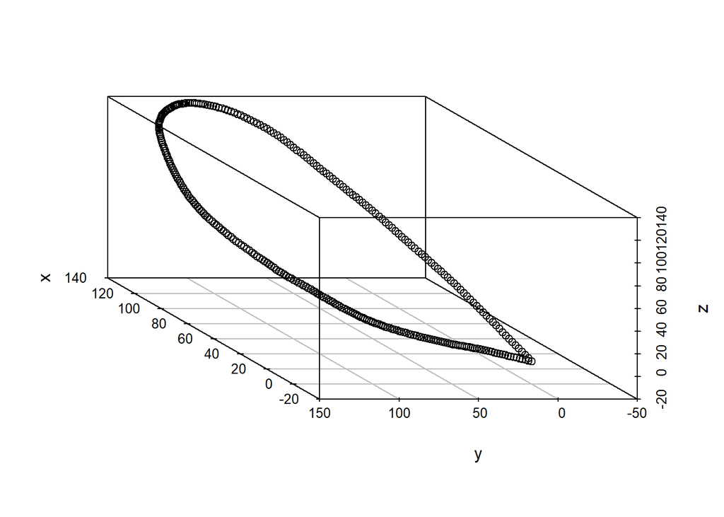

```r
x <- long_format$X[316:630]
y <- long_format$Y[316:630]
z <- long_format$Z[316:630]
sample_plot <- data.frame(x,y,z)
scatterplot3d(sample_plot[1:3], angle=300)
```

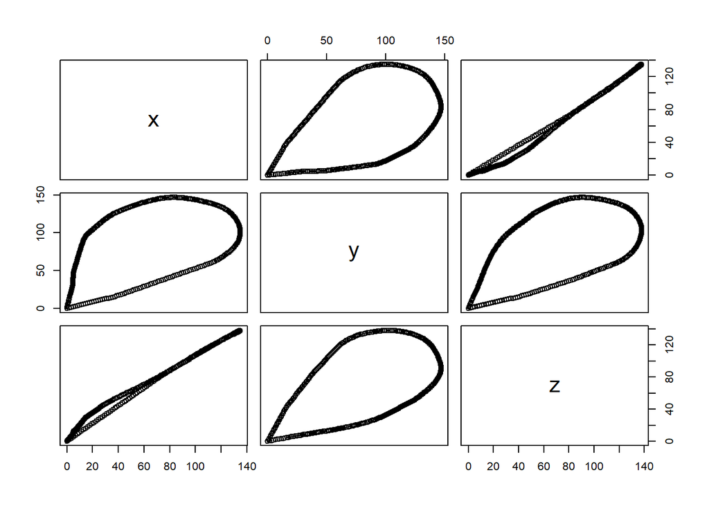

```r
plot(sample_plot)
```

The time series id for this particular instance is 5 which corresponds to a gesture that starts from the bottom and simply goes upwards linearly. On the other hand, the 3D plot has a circular shape. However, it should be remembered that this result is given by the velocity data. An additional cummulative sum to compute the position data may result in a straight line.

# PART B

```r
pca <- princomp(long_format[,3:5], cor = T)
summary(pca, loadings = T)
```

```
## Importance of components:
##                           Comp.1    Comp.2    Comp.3
## Standard deviation     1.2548918 1.0329813 0.5984948
## Proportion of Variance 0.5249179 0.3556835 0.1193987
## Cumulative Proportion  0.5249179 0.8806013 1.0000000
##
## Loadings:
##   Comp.1 Comp.2 Comp.3
## X  0.233  0.901  0.365
## Y  0.723        -0.685
## Z  0.651 -0.423  0.631
```

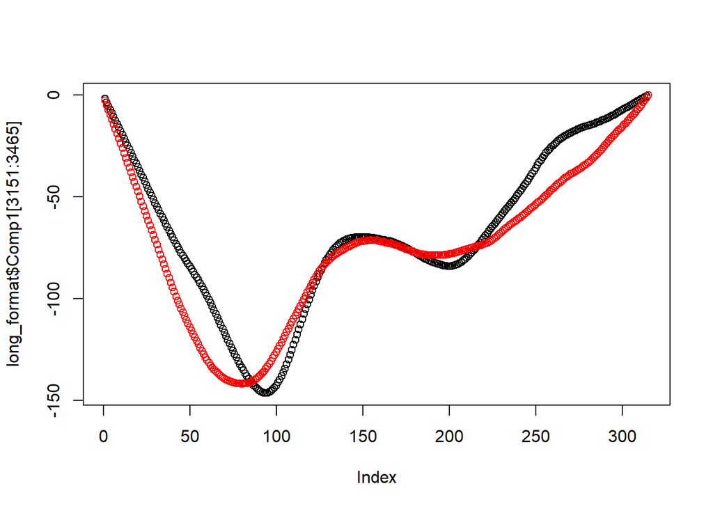

```r
long_format <- as.data.table(long_format)
long_format[, Comp1 := 0.233*X + 0.723*Y + 0.651*Z]

#class 1
plot(long_format$Comp1[3151:3465])
points(long_format$Comp1[5041:5355], col = "red")
```

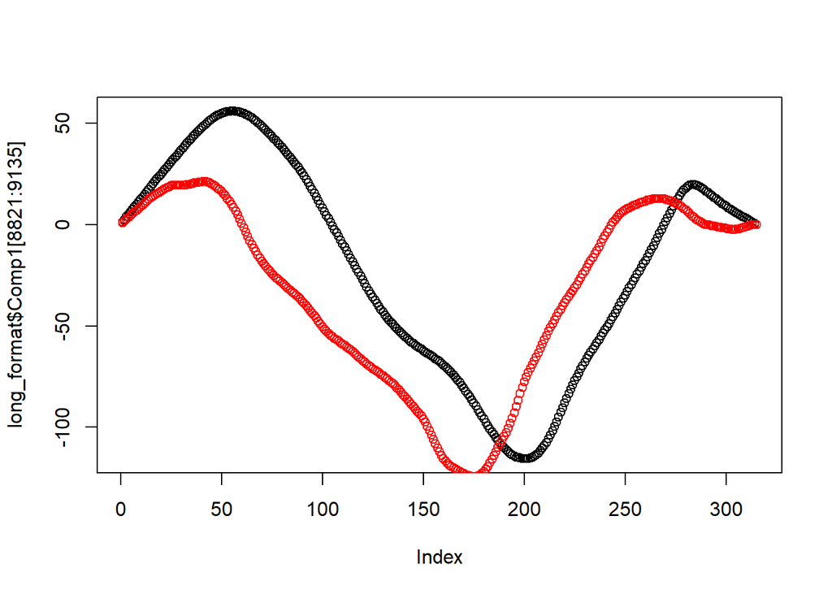

```r
#class 2
plot(long_format$Comp1[8821:9135])
points(long_format$Comp1[5986:6300], col = "red")
```

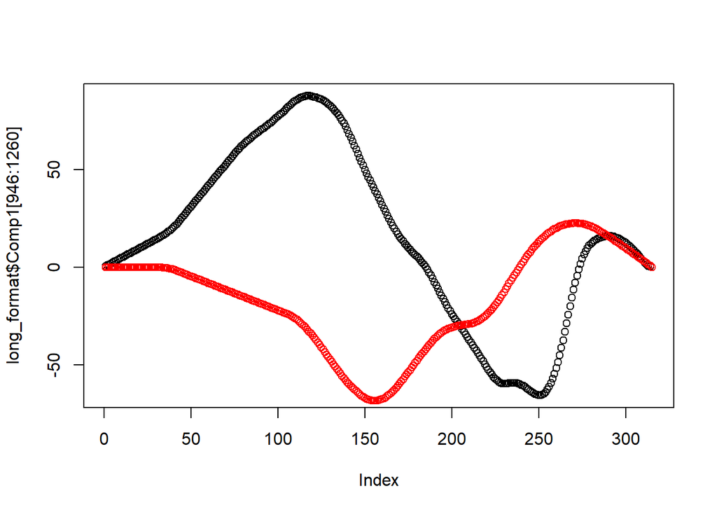

```r
#class 3
plot(long_format$Comp1[946:1260])
points(long_format$Comp1[3781:4095], col = "red")
```

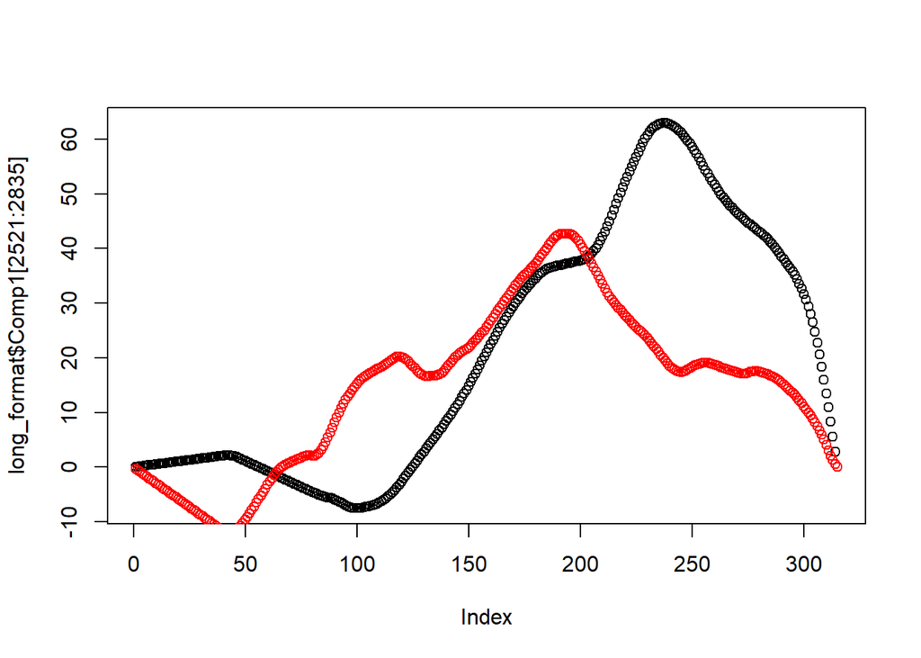

```r
#class 4
plot(long_format$Comp1[2521:2835])
points(long_format$Comp1[1261:1575], col = "red")
```

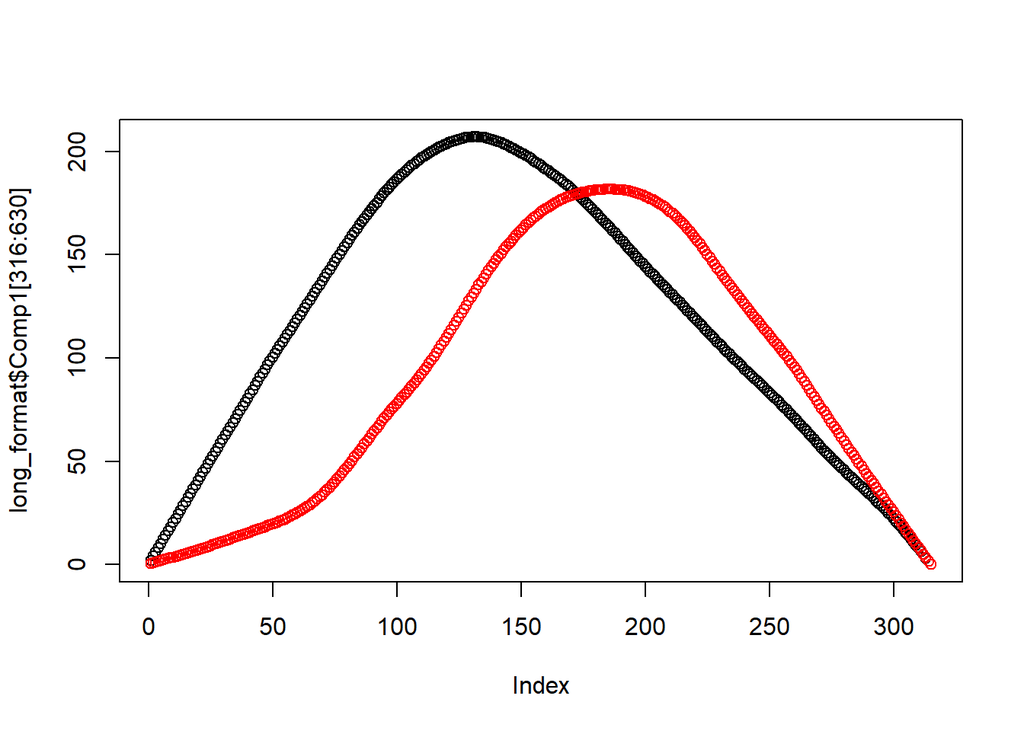

```r
#class 5
plot(long_format$Comp1[316:630])
points(long_format$Comp1[631:945], col = "red")
```

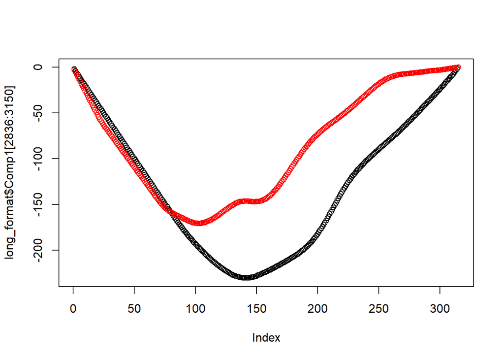

```r
#class 6
plot(long_format$Comp1[2836:3150])
points(long_format$Comp1[1:315], col = "red")
```

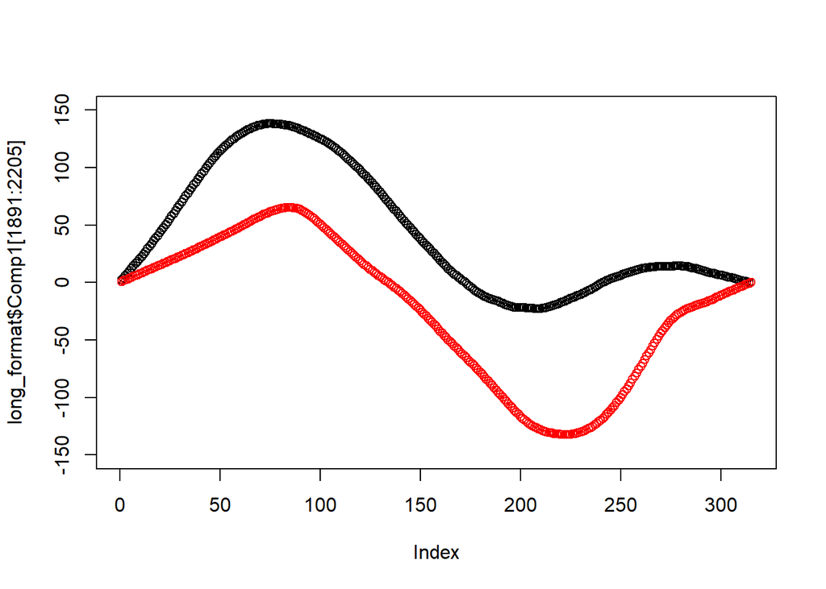

```r
#class 7
plot(long_format$Comp1[1891:2205], ylim = c(-150, 150))
points(long_format$Comp1[3466:3780], col = "red")
```

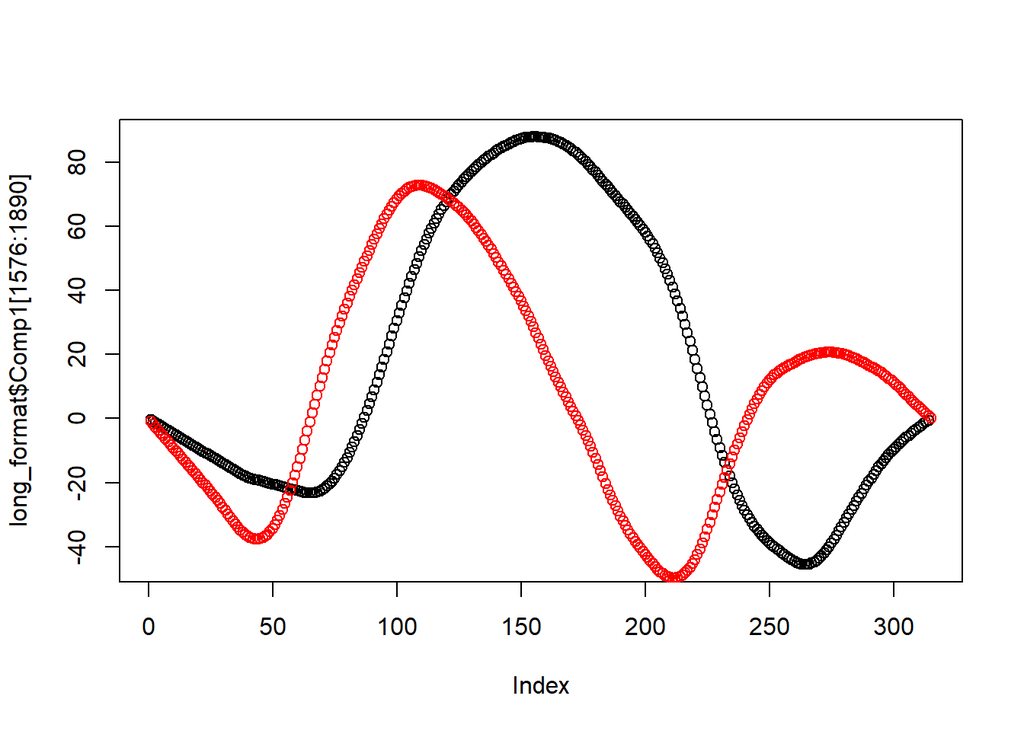

```r
#class 8
plot(long_format$Comp1[1576:1890])
points(long_format$Comp1[6301:6615], col = "red")
```

# PART C

```r
#1
long_format_1 <- long_format[`Time Series ID`== 1,]
pca_1 <- princomp(long_format_1[,3:5], cor = T)
summary(pca_1, loadings = T)
```

```
## Importance of components:
##                           Comp.1    Comp.2    Comp.3
## Standard deviation     1.2515597 0.9418773 0.7392331
## Proportion of Variance 0.5221339 0.2957109 0.1821552
## Cumulative Proportion  0.5221339 0.8178448 1.0000000
##
## Loadings:
##   Comp.1 Comp.2 Comp.3
## X  0.489  0.784  0.382
## Y  0.563 -0.619  0.548
## Z  0.666        -0.744
```

```r
#2
long_format_2 <- long_format[`Time Series ID`== 2,]
pca_2 <- princomp(long_format_2[,3:5], cor = T)
summary(pca_2, loadings = T)
```

```
## Importance of components:
##                           Comp.1    Comp.2     Comp.3
## Standard deviation     1.3240367 0.9829023 0.52993383
## Proportion of Variance 0.5843577 0.3220323 0.09360995
## Cumulative Proportion  0.5843577 0.9063900 1.00000000
##
## Loadings:
##   Comp.1 Comp.2 Comp.3
## X  0.212  0.976
## Y  0.694 -0.116 -0.710
## Z  0.688 -0.184  0.702
```

```r
#3
long_format_3 <- long_format[`Time Series ID`== 3,]
pca_3 <- princomp(long_format_3[,3:5], cor = T)
summary(pca_3, loadings = T)
```

```
## Importance of components:
##                           Comp.1    Comp.2    Comp.3
## Standard deviation     1.2231551 0.9847813 0.7308196
## Proportion of Variance 0.4987028 0.3232647 0.1780324
## Cumulative Proportion  0.4987028 0.8219676 1.0000000
##
## Loadings:
##   Comp.1 Comp.2 Comp.3
## X  0.696         0.718
## Y  0.483 -0.745 -0.461
## Z -0.531 -0.668  0.521
```

```r
#4
long_format_4 <- long_format[`Time Series ID`== 4,]
pca_4 <- princomp(long_format_4[,3:5], cor = T)
summary(pca_4, loadings = T)
```

```
## Importance of components:
##                           Comp.1    Comp.2    Comp.3
## Standard deviation     1.2197403 0.9944978 0.7233311
## Proportion of Variance 0.4959221 0.3296753 0.1744026
## Cumulative Proportion  0.4959221 0.8255974 1.0000000
##
## Loadings:
##   Comp.1 Comp.2 Comp.3
## X  0.703         0.711
## Y  0.665  0.327 -0.671
## Z -0.252  0.945  0.211
```

```r
#5
long_format_5 <- long_format[`Time Series ID`== 5,]
pca_5 <- princomp(long_format_5[,3:5], cor = T)
summary(pca_5, loadings = T)
```

```
## Importance of components:
##                           Comp.1    Comp.2     Comp.3
## Standard deviation     1.3469481 0.9721290 0.49060790
## Proportion of Variance 0.6047564 0.3150116 0.08023204
## Cumulative Proportion  0.6047564 0.9197680 1.00000000
##
## Loadings:
##   Comp.1 Comp.2 Comp.3
## X  0.258  0.964
## Y  0.678 -0.228  0.699
## Z  0.689 -0.137 -0.712
```

```r
#6
long_format_6 <- long_format[`Time Series ID`== 6,]
pca_6 <- princomp(long_format_6[,3:5], cor = T)
summary(pca_6, loadings = T)
```

```
## Importance of components:
##                           Comp.1    Comp.2     Comp.3
## Standard deviation     1.3274411 0.9781758 0.53016247
## Proportion of Variance 0.5873666 0.3189426 0.09369075
## Cumulative Proportion  0.5873666 0.9063093 1.00000000
##
## Loadings:
##   Comp.1 Comp.2 Comp.3
## X  0.241  0.968
## Y -0.680  0.224 -0.698
## Z -0.692  0.118  0.712
```

```r
#7
long_format_7 <- long_format[`Time Series ID`== 7,]
pca_7 <- princomp(long_format_7[,3:5], cor = T)
summary(pca_7, loadings = T)
```

```
## Importance of components:
##                           Comp.1    Comp.2    Comp.3
## Standard deviation     1.2584492 0.9833228 0.6703595
## Proportion of Variance 0.5278981 0.3223079 0.1497939
## Cumulative Proportion  0.5278981 0.8502061 1.0000000
##
## Loadings:
##   Comp.1 Comp.2 Comp.3
## X  0.399  0.846  0.354
## Y  0.696        -0.717
## Z  0.597 -0.533  0.600
```

```r
#8
long_format_8 <- long_format[`Time Series ID`== 8,]
pca_8 <- princomp(long_format_8[,3:5], cor = T)
summary(pca_8, loadings = T)
```

```
## Importance of components:
##                           Comp.1    Comp.2    Comp.3
## Standard deviation     1.2787572 0.9315413 0.7049899
## Proportion of Variance 0.5450733 0.2892564 0.1656703
## Cumulative Proportion  0.5450733 0.8343297 1.0000000
##
## Loadings:
##   Comp.1 Comp.2 Comp.3
## X  0.582  0.561  0.588
## Y  0.663        -0.743
## Z  0.471 -0.823  0.319
```

# PART D

```r
# creating original format
data_y[,1] <- NULL
data_z[,1] <- NULL

original_format <- cbind(data_x, data_y, data_z)

# MDS
distance_matrix <- dist(original_format[,2:946])
fit <- cmdscale(distance_matrix, k = 2)
fit
```

```
##                 [,1]          [,2]
##   [1,]  1614.5734809   603.9993574
##   [2,] -2439.2994209   547.3045362
##   [3,] -1849.1010299   289.6327331
##   [4,]  -487.7827987 -1182.6243755
##   [5,]  -492.2105588  1972.9998447
##   [6,]  -557.3505825   -71.0109357
##   [7,]  -793.8256911   -65.5325861
##   [8,]   686.9180167  1427.1575057
##   [9,]  -535.2638414  2190.5098738
##  [10,]  2488.5956056  -974.4733256
##  [11,]  1297.7280698   -36.5136351
##  [12,]   430.2154685 -1043.4690465
##  [13,]   483.6178855 -2069.3122503
##  [14,]  -318.4130080   121.0348833
```

[output cut: 882 more lines]

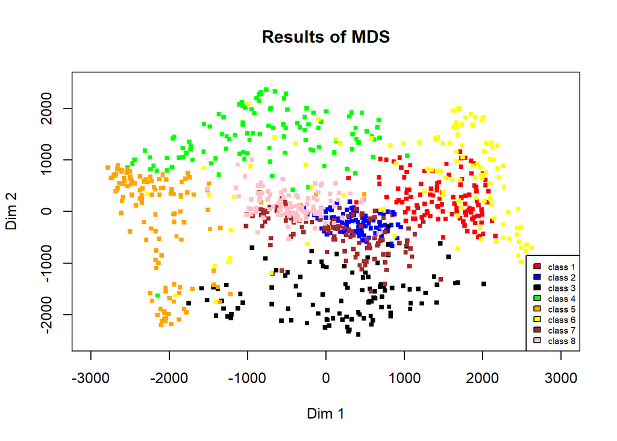

```r
fit <- cbind(fit, original_format[,1])

fit_1 <- fit[fit[,3] == 1,]
fit_2 <- fit[fit[,3] == 2,]
fit_3 <- fit[fit[,3] == 3,]
fit_4 <- fit[fit[,3] == 4,]
fit_5 <- fit[fit[,3] == 5,]
fit_6 <- fit[fit[,3] == 6,]
fit_7 <- fit[fit[,3] == 7,]
fit_8 <- fit[fit[,3] == 8,]

plot(x = fit_1[,1], y = fit_1[,2], col = "red", pch = ".", cex = 5,
     xlim = c(-3000, 3000), ylim = c(-2500, 2500), xlab = "Dim 1", ylab = "Dim 2", main = "Results of MDS")
points(x = fit_2[,1], y = fit_2[,2], col = "blue", pch = ".", cex = 5)
points(x = fit_3[,1], y = fit_3[,2], col = "black", pch = ".", cex = 5)
points(x = fit_4[,1], y = fit_4[,2], col = "green", pch = ".", cex = 5)
points(x = fit_5[,1], y = fit_5[,2], col = "orange", pch = ".", cex = 5)
points(x = fit_6[,1], y = fit_6[,2], col = "yellow", pch = ".", cex = 5)
points(x = fit_7[,1], y = fit_7[,2], col = "brown", pch = ".", cex = 5)
points(x = fit_8[,1], y = fit_8[,2], col = "pink", pch = ".", cex = 5)
legend("bottomright", c("class 1","class 2", "class 3", "class 4", "class 5", "class 6", "class 7", "class 8"),
       fill = c("red","blue", "black", "green", "orange", "yellow", "brown", "pink"), cex = 0.6)
```

After the application of multi-dimensşonal scaling, it is observed that the model was partially successful in distinguishing between classes. When the plot is inspected, it is noticed that some location for each class where it has more density is present. There exist, however, some parts where two or more classes are pretty mixed.